# Hierarchical modelling tutorial

This notebook is a tutorial on Hierarchical modelling using Stan that accompanies the youtube video https://youtu.be/dNZQrcAjgXQ

```r
require(rstan)
set.seed(1) #set seed
```

First we read in the data

```r
data = read.csv('/Users/maggielieu/Desktop/STAN/GITHUB/STAN_tutorials/Hierarchical/premiereleague.csv',col.names = c('Home','score1', 'score2', 'Away'), stringsAsFactors = FALSE)
```

```r
data
```

| Home | score1 | score2 | Away |
| --- | --- | --- | --- |
| West Ham United | 0 | 5 | Manchester City |
| Burnley | 3 | 0 | Southampton |
| Crystal Palace | 0 | 0 | Everton |
| Watford | 0 | 3 | Brighton & Hove Albion |
| AFC Bournemouth | 1 | 1 | Sheffield United |
| Tottenham Hotspur | 3 | 1 | Aston Villa |
| Leicester City | 0 | 0 | Wolverhampton Wanderers |
| Newcastle United | 0 | 1 | Arsenal |
| Manchester United | 4 | 0 | Chelsea |
| Arsenal | 2 | 1 | Burnley |

[output cut: 318 more lines]

```r
ng = nrow(data)
cat('we have G =', ng, 'games \n')
```

```
we have G = 328 games
```

```r
nt = length(unique(data$Home))
cat('we have T = ', nt, 'teams \n')
```

```
we have T =  20 teams
```

# Traditional method

We will assume that the goals scored come from a poisson distribution s1 | theta_g1 ~ Poisson(theta_g1) #game g score by home team s2 | theta_g2 ~ Poisson(theta_g2) #game g score by away team

Assuming a log-linear random effect model log(theta_g1) = home + att_ht + def_at log(theta_g2) = att_at + def_ht

where home is a constant for the advantage for the team hosting the game att and def are the attack and defence abilities of the teams where the indices at,ht correspond to the t=1-20 teams.

priors we willl use for the attack and defence abilities are very wide, essentially the teams’ performances are independent of each other home ~ normal(0,0.0001) att[t] ~ normal(0, 2) def[t] ~ normal(0, 2)

Now convert team names for each match into numbers

```r
teams = unique(data$Home)
ht = unlist(sapply(1:ng, function(g) which(teams == data$Home[g])))
at = unlist(sapply(1:ng, function(g) which(teams == data$Away[g])))
```

```r
# we will save the last 5 games to predict
np=5
ngob = ng-np #number of games to fit
my_data = list(
  nt = nt,
  ng = ngob,
  ht = ht[1:ngob],
  at = at[1:ngob],
  s1 = data$score1[1:ngob],
  s2 = data$score2[1:ngob],
  np = np,
  htnew = ht[(ngob+1):ng],
  atnew = at[(ngob+1):ng]
)
```

```r
nhfit = stan(file = 'non_hier_model.stan', data = my_data)
```

[output not shown]

```r
print(nhfit)
```

```
Inference for Stan model: non_hier_model.
4 chains, each with iter=2000; warmup=1000; thin=1;
post-warmup draws per chain=1000, total post-warmup draws=4000.

                mean se_mean   sd    2.5%     25%     50%     75%   97.5% n_eff Rhat
home            0.00    0.00 0.00    0.00    0.00    0.00    0.00    0.00  3797 1.00
att[1]          0.02    0.05 0.35   -0.69   -0.21    0.03    0.26    0.69    60 1.04
att[2]         -0.08    0.05 0.36   -0.81   -0.32   -0.07    0.16    0.62    62 1.03
att[3]         -0.36    0.05 0.37   -1.09   -0.60   -0.36   -0.11    0.33    65 1.03
att[4]         -0.27    0.05 0.36   -0.98   -0.51   -0.26   -0.02    0.43    64 1.03
att[5]         -0.20    0.05 0.35   -0.90   -0.43   -0.20    0.05    0.51    62 1.03
att[6]          0.28    0.05 0.34   -0.41    0.05    0.29    0.52    0.93    56 1.04
att[7]          0.44    0.05 0.34   -0.25    0.23    0.45    0.68    1.08    55 1.04
att[8]         -0.16    0.05 0.36   -0.88   -0.40   -0.16    0.09    0.50    60 1.04
att[9]          0.35    0.05 0.34   -0.34    0.13    0.36    0.58    0.99    56 1.04
att[10]         0.21    0.05 0.34   -0.47   -0.02    0.21    0.44    0.84    57 1.04
att[11]        -0.06    0.05 0.35   -0.80   -0.30   -0.05    0.18    0.61    59 1.04
att[12]         0.06    0.05 0.35   -0.65   -0.16    0.06    0.30    0.74    57 1.04
att[13]        -0.46    0.05 0.38   -1.23   -0.71   -0.45   -0.21    0.22    66 1.03
att[14]         0.07    0.05 0.35   -0.65   -0.16    0.08    0.32    0.74    58 1.04
att[15]        -0.13    0.05 0.36   -0.86   -0.37   -0.12    0.11    0.58    60 1.04
att[16]         0.77    0.05 0.33    0.08    0.55    0.77    1.01    1.40    52 1.04
att[17]        -0.17    0.05 0.36   -0.93   -0.41   -0.17    0.08    0.51    60 1.04
att[18]         0.38    0.05 0.34   -0.28    0.15    0.38    0.61    1.02    55 1.04
att[19]         0.11    0.05 0.35   -0.58   -0.13    0.11    0.34    0.77    59 1.04
att[20]         0.57    0.05 0.34   -0.13    0.34    0.58    0.80    1.22    53 1.04
def[1]         -0.38    0.05 0.34   -1.06   -0.61   -0.37   -0.14    0.27    55 1.04
def[2]         -0.18    0.05 0.35   -0.87   -0.41   -0.17    0.06    0.49    56 1.04
def[3]         -0.04    0.05 0.35   -0.73   -0.28   -0.03    0.19    0.64    60 1.04
def[4]         -0.28    0.05 0.35   -0.96   -0.52   -0.28   -0.04    0.39    56 1.04
def[5]         -0.46    0.05 0.34   -1.15   -0.69   -0.46   -0.23    0.20    56 1.04
def[6]         -0.17    0.05 0.35   -0.89   -0.40   -0.16    0.06    0.50    59 1.04
def[7]          0.18    0.05 0.36   -0.54   -0.06    0.19    0.43    0.89    63 1.03
def[8]         -0.17    0.05 0.35   -0.87   -0.39   -0.16    0.08    0.52    58 1.04
def[9]          0.14    0.05 0.35   -0.58   -0.10    0.14    0.38    0.81    61 1.04
def[10]        -0.10    0.05 0.35   -0.81   -0.34   -0.10    0.13    0.56    59 1.04
def[11]        -0.49    0.05 0.34   -1.20   -0.72   -0.49   -0.25    0.18    54 1.04
def[12]        -0.22    0.05 0.35   -0.94   -0.45   -0.22    0.01    0.46    56 1.04
def[13]        -0.45    0.05 0.34   -1.13   -0.67   -0.44   -0.22    0.22    56 1.04
def[14]        -0.41    0.05 0.34   -1.10   -0.64   -0.40   -0.18    0.25    55 1.04
```

[output cut: 56 more lines]

```
theta1[51]      1.89    0.00 0.38    1.25    1.62    1.86    2.12    2.72  7623 1.00
theta1[52]      2.90    0.01 0.54    1.95    2.52    2.86    3.24    4.09  8473 1.00
theta1[53]      0.95    0.00 0.22    0.57    0.79    0.93    1.08    1.44  6979 1.00
theta1[54]      1.48    0.00 0.33    0.93    1.25    1.45    1.67    2.20  7590 1.00
theta1[55]      1.03    0.00 0.24    0.62    0.86    1.01    1.18    1.55  6330 1.00
theta1[56]      0.92    0.00 0.22    0.55    0.76    0.89    1.05    1.40  6148 1.00
theta1[57]      0.67    0.00 0.17    0.39    0.55    0.65    0.77    1.05  5461 1.00
theta1[58]      2.05    0.00 0.40    1.37    1.76    2.01    2.30    2.91  7828 1.00
theta1[59]      1.01    0.00 0.25    0.59    0.84    0.99    1.16    1.56  5344 1.00
 [ reached getOption("max.print") -- omitted 608 rows ]

Samples were drawn using NUTS(diag_e) at Mon Jul 27 22:25:48 2020.
For each parameter, n_eff is a crude measure of effective sample size,
and Rhat is the potential scale reduction factor on split chains (at
convergence, Rhat=1).
```

`Plot the predicted scores of the last 5 matches

```r
nhparams = extract(nhfit)
pred_scores = c(colMeans(nhparams$s1new),colMeans(nhparams$s2new))
true_scores = c(data$score1[(ngob+1):ng],data$score2[(ngob+1):ng] )
plot(true_scores, pred_scores, xlim=c(0,5), ylim=c(0,5), pch=20, ylab='predicted scores', xlab='true scores')
abline(a=0,  b=1, lty='dashed')
```

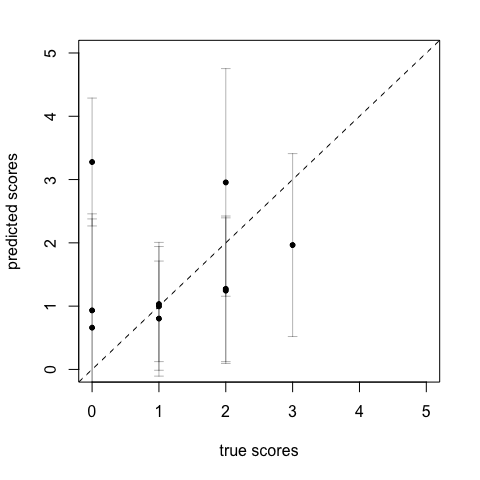

```r
pred_errors = c(sapply(1:np, function(x) sd(nhparams$s1new[,x])),sapply(1:np, function(x) sd(nhparams$s1new[,x])))
arrows(true_scores, pred_scores+pred_errors, true_scores, pred_scores-pred_errors, length = 0.05, angle = 90, code = 3, col=rgb(0,0,0,0.3))
```

We can also look at the attack/defense of the teams:

```r
attack = colMeans(nhparams$att)
defense = colMeans(nhparams$def)

plot(attack,defense,xlim=c(-0.4,1.1))
abline(h=0)
```

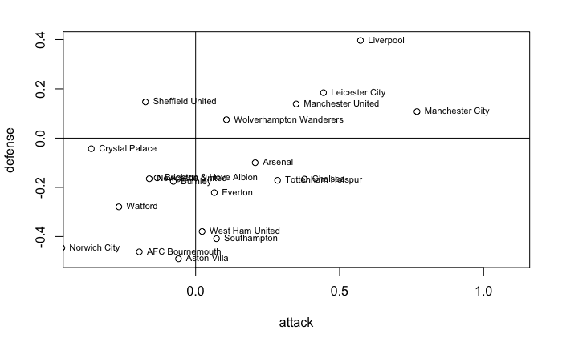

```r
abline(v=0)
text(attack,defense, labels=teams, cex=0.7, pos=4)
```

Or we can assume all of the abilities are the same, or at least very similar by setting a very tight prior on the attack and defence abilities N(0,0.001), essentially restricting the teams to have the same performance

```r
nhpoolfit = stan(file = 'non_hier_model_pool.stan', data = my_data)
```

Again we can plot the predicted scores of the last 5 matches, note now how the predicted scores are all the same.

```r
nhpoolparams = extract(nhpoolfit)
pred_scores = c(colMeans(nhpoolparams$s1new),colMeans(nhpoolparams$s2new))
pred_errors = c(sapply(1:np, function(x) sd(nhpoolparams$s1new[,x])),sapply(1:np, function(x) sd(nhpoolparams$s1new[,x])))
true_scores = c(data$score1[(ngob+1):ng],data$score2[(ngob+1):ng] )
plot(true_scores, pred_scores, xlim=c(0,4), ylim=c(0,4), pch=20, ylab='predicted scores', xlab='true scores')
abline(a=0,  b=1, lty='dashed')
```

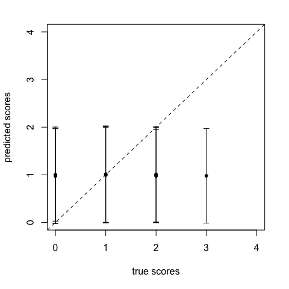

```r
arrows(true_scores, pred_scores+pred_errors, true_scores, pred_scores-pred_errors, length = 0.05, angle = 90, code = 3)
```

and similarly the teams’ attack and defense abilities are all close to 0.

```r
attack = colMeans(nhpoolparams$att)
defense = colMeans(nhpoolparams$def)

plot(attack,defense,xlim=c(-0.4,1.1))
abline(h=0)
```

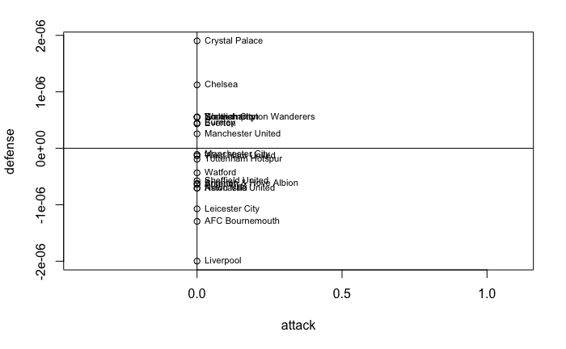

```r
abline(v=0)
text(attack,defense, labels=teams, cex=0.7, pos=4)
```

# Hierarchical model

In a hierarchical model, the parameters of interest, in our case the attack and defense ability are drawn from the population distribution. att[t] ~ normal(mu_att, tau_att) def[t] ~ normal(mu_def, tau_def)

```r
hfit = stan(file = 'hier_model.stan', data = my_data)
```

```
recompiling to avoid crashing R session
```

```r
print(hfit)
```

[output not shown]

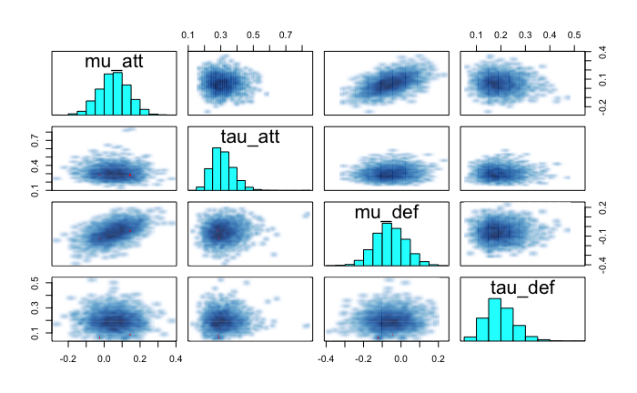

```r
pairs(hfit, pars=c('mu_att', 'tau_att', 'mu_def', 'tau_def'))
```

```r
hparams = extract(hfit)
pred_scores = c(colMeans(hparams$s1new),colMeans(hparams$s2new))
pred_errors = c(sapply(1:np, function(x) sd(hparams$s1new[,x])),sapply(1:np, function(x) sd(hparams$s1new[,x])))
true_scores = c(data$score1[(ngob+1):ng],data$score2[(ngob+1):ng] )
plot(true_scores, pred_scores, xlim=c(0,5), ylim=c(0,5), pch=20, ylab='predicted scores', xlab='true scores')
abline(a=0,  b=1, lty='dashed')
```

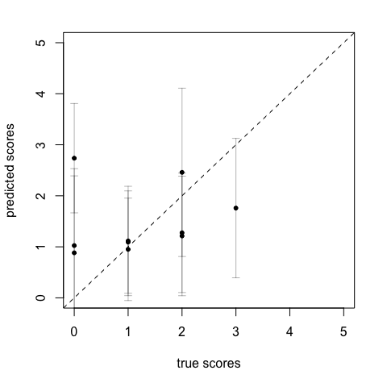

```r
arrows(true_scores, pred_scores+pred_errors, true_scores, pred_scores-pred_errors, length = 0.05, angle = 90, code = 3, rgb(0,0,0,0.3))
```

```r
attack = colMeans(hparams$att)
attacksd = sapply(1:nt, function(x) sd(hparams$att[,x]))
defense = colMeans(hparams$def)
defensesd = sapply(1:nt, function(x) sd(hparams$def[,x]))

plot(attack,defense, xlim=c(-0.4,1), ylim=c(-0.45,0.3), pch=20)
arrows(attack-attacksd, defense, attack+attacksd, defense, code=3, angle = 90, length = 0.04, col=rgb(0,0,0,0.2))
```

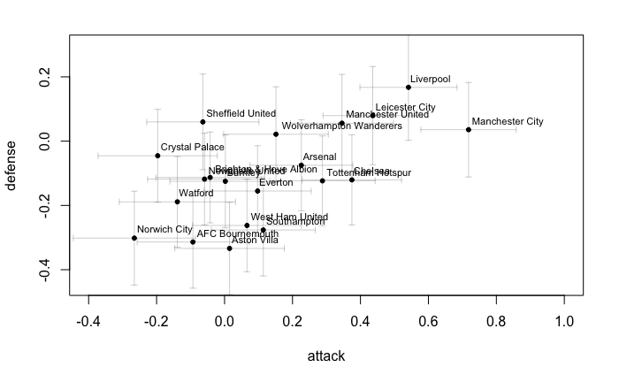

```r
arrows(attack, defense-defensesd, attack, defense+defensesd, code=3, angle = 90, length = 0.04,col=rgb(0,0,0,0.2))
#abline(h=0)
#abline(v=0)
text(attack,defense, labels=teams, cex=0.7, adj=c(-0.05,-0.8) )
```